# INDEX

## WEATHER IMPACT

### 1. What is the correlation between temperature and the number of pickups?

```python
correlation = df['temp'].corr(df['pickups'])
print("Correlation between temperature and pickups:", correlation)
```

```
Correlation between temperature and pickups: 0.06851304320789024
```

### 2. How does visibility impact the number of pickups?

```
Correlation between visibility and pickups: -0.007474433707060333
```

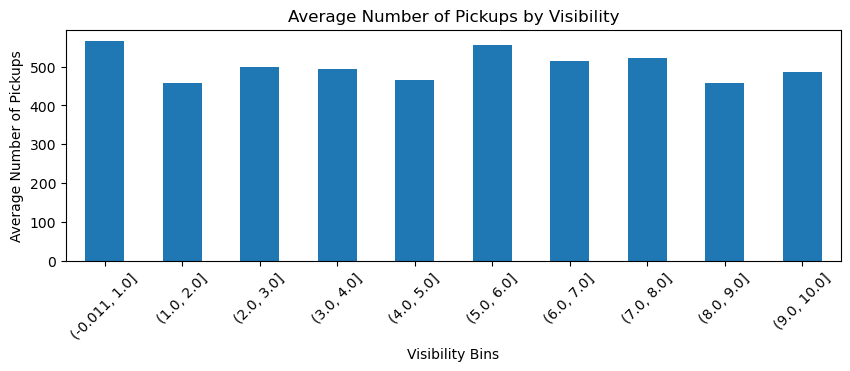

```python
correlation_pickups = df['vsb'].corr(df['pickups'])
print("Correlation between visibility and pickups:", correlation_pickups)

df['vsb_bins'] = pd.cut(df['vsb'], bins=10, include_lowest=True)

average_pickups_vsb = df.groupby('vsb_bins', observed=True)['pickups'].mean()

plt.figure(figsize=(10, 3))
average_pickups_vsb.plot(kind='bar')
plt.title('Average Number of Pickups by Visibility')
plt.xlabel('Visibility Bins')
plt.ylabel('Average Number of Pickups')
plt.xticks(rotation=45)
plt.show()
```

### 3. Is there a relationship between wind speed and the number of pickups?

```
Correlation between wind speed and pickups: 0.011110156997631699
```

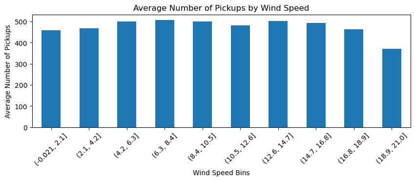

```python
correlation_spd = df['spd'].corr(df['pickups'])
print("Correlation between wind speed and pickups:", correlation_spd)

df['spd_bins'] = pd.cut(df['spd'], bins=10)
average_pickups_spd = df.groupby('spd_bins', observed=True)['pickups'].mean()

plt.figure(figsize=(10, 3))
average_pickups_spd.plot(kind='bar')
plt.title('Average Number of Pickups by Wind Speed')
plt.xlabel('Wind Speed Bins')
plt.ylabel('Average Number of Pickups')
plt.xticks(rotation=45)
plt.show()
```

### 4. How does precipitation (1-hour, 6-hour, 24-hour) affect the number of pickups?

```python
correlation_pcp01 = df['pcp01'].corr(df['pickups'])
correlation_pcp06 = df['pcp06'].corr(df['pickups'])
correlation_pcp24 = df['pcp24'].corr(df['pickups'])

print("Correlation between 1-hour precipitation and pickups:", correlation_pcp01)
print("Correlation between 6-hour precipitation and pickups:", correlation_pcp06)
print("Correlation between 24-hour precipitation and pickups:", correlation_pcp24)
```

```
Correlation between 1-hour precipitation and pickups: -0.007967284671963636
Correlation between 6-hour precipitation and pickups: 0.0058164541143686495
Correlation between 24-hour precipitation and pickups: -0.005404637226941016
```

## SEASONAL TRENDS

### 1. How do the number of pickups vary across different seasons (winter, spring, summer, fall)?

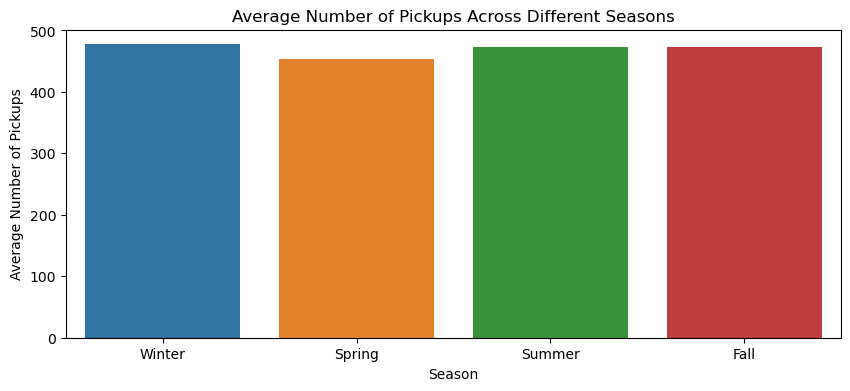

```python
df['pickup_dt'] = pd.to_datetime(df['pickup_dt'], errors='coerce')
def get_season(month):
    if month in [12, 1, 2]:
        return 'Winter'
    elif month in [3, 4, 5]:
        return 'Spring'
    elif month in [6, 7, 8]:
        return 'Summer'
    elif month in [9, 10, 11]:
        return 'Fall'

df['month'] = df['pickup_dt'].dt.month
df['season'] = df['month'].apply(get_season)


season_pickups = df.groupby('season')['pickups'].mean().reset_index()

season_order = ['Winter', 'Spring', 'Summer', 'Fall']

plt.figure(figsize=(10, 4))
sns.barplot(x='season', y='pickups', data=season_pickups, order=season_order)
plt.title('Average Number of Pickups Across Different Seasons')
plt.xlabel('Season')
plt.ylabel('Average Number of Pickups')
plt.show()
```

### 2. What is the average number of pickups during holidays compared to non-holidays?

```python
df['hday'] = df['hday'].apply(lambda x: 1 if x == 'Y' else 0)

holiday_pickups = df.groupby('hday')['pickups'].mean()
print(holiday_pickups)
```

```
hday
0    490.236022
Name: pickups, dtype: float64
```

### 3. How does snow depth influence the number of pickups?

```
Correlation between snow depth and pickups: -0.013425090828264189
```

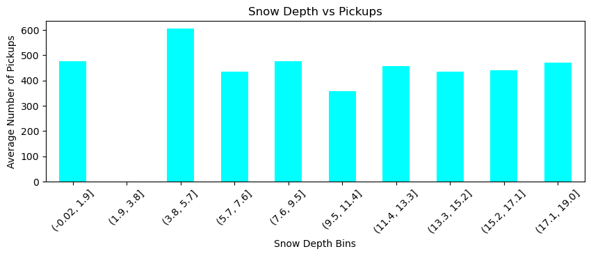

```python
correlation_sd = df['sd'].corr(df['pickups'])
print("Correlation between snow depth and pickups:", correlation_sd)

df['sd_bins'] = pd.cut(df['sd'], bins=10, include_lowest=True)

plt.figure(figsize=(10, 3))
df.groupby('sd_bins', observed=False)['pickups'].mean().plot(kind='bar', color='cyan')
plt.title('Snow Depth vs Pickups')
plt.xlabel('Snow Depth Bins')
plt.ylabel('Average Number of Pickups')
plt.xticks(rotation=45)
plt.show()
```

## HOURLY TRENDS

### 1. What are the peak hours for Uber pickups in each borough?

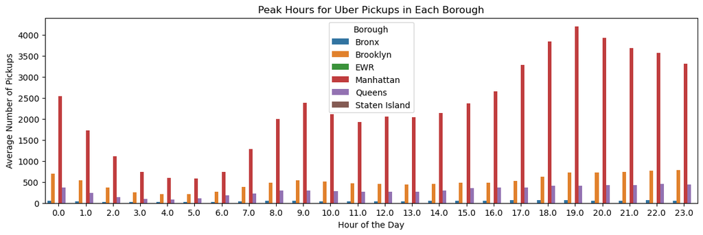

```python
df['pickup_dt'] = pd.to_datetime(df['pickup_dt'], errors='coerce')

df['hour'] = df['pickup_dt'].dt.hour
peak_hours = df.groupby(['borough', 'hour'])['pickups'].mean().reset_index()

# Plotting
plt.figure(figsize=(14, 4))
sns.barplot(data=peak_hours, x='hour', y='pickups', hue='borough')
plt.title('Peak Hours for Uber Pickups in Each Borough')
plt.xlabel('Hour of the Day')
plt.ylabel('Average Number of Pickups')
plt.legend(title='Borough')
plt.show()
```

### 2. How do the number of pickups change during rush hours (e.g., 7-9 AM, 5-7 PM)?

```python
df['pickup_dt'] = pd.to_datetime(df['pickup_dt'], errors='coerce')
df['hour'] = df['pickup_dt'].dt.hour

rush_morning = [7, 8, 9]
rush_evening = [17, 18, 19]

morning_pickups = df[df['hour'].isin(rush_morning)].groupby('hour')['pickups'].mean()
evening_pickups = df[df['hour'].isin(rush_evening)].groupby('hour')['pickups'].mean()

print("Average pickups during morning rush hours:",morning_pickups)
print("\nAverage pickups during evening rush hours:",evening_pickups)
```

```
Average pickups during morning rush hours: hour
7.0    286.163934
8.0    424.556936
9.0    482.843943
Name: pickups, dtype: float64

Average pickups during evening rush hours: hour
17.0    626.764344
18.0    730.893443
19.0    797.774127
Name: pickups, dtype: float64
```

### 3. What is the average number of pickups during late-night hours (e.g., 12 AM - 4 AM)?

```python
df['pickup_dt'] = pd.to_datetime(df['pickup_dt'], errors='coerce')
df['hour'] = df['pickup_dt'].dt.hour

late_night_hours = [0, 1, 2, 3, 4]

late_night_pickups = df[df['hour'].isin(late_night_hours)].groupby('hour')['pickups'].mean()
print("Average pickups during late-night hours:\n", late_night_pickups)
```

```
Average pickups during late-night hours:
 hour
0.0    549.811441
1.0    386.981013
2.0    253.736052
3.0    172.779221
4.0    140.923913
Name: pickups, dtype: float64
```

## BOROUGH COMPARISON

### 1. How do pickup trends differ between boroughs during different weather conditions?

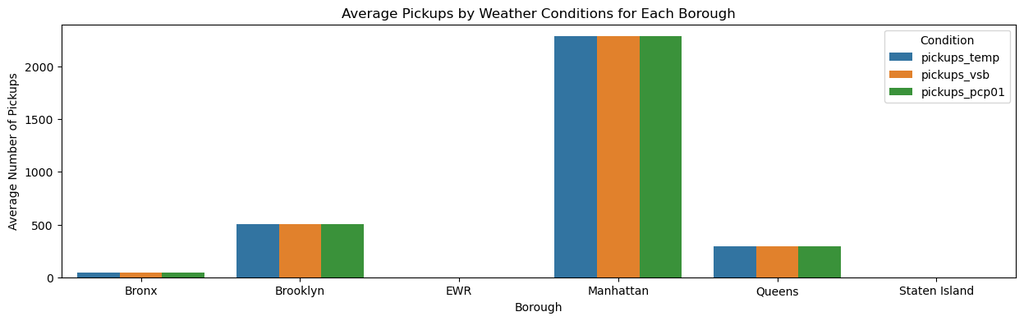

```python
df['pickup_dt'] = pd.to_datetime(df['pickup_dt'], dayfirst=True, errors='coerce')

df = df.dropna(subset=['pickup_dt'])

avg_pickups_by_temp = df.groupby('borough')[['temp', 'pickups']].mean().reset_index()
avg_pickups_by_vsb = df.groupby('borough')[['vsb', 'pickups']].mean().reset_index()
avg_pickups_by_pcp01 = df.groupby('borough')[['pcp01', 'pickups']].mean().reset_index()

avg_pickups_by_temp.rename(columns={'pickups': 'pickups_temp'}, inplace=True)
avg_pickups_by_vsb.rename(columns={'pickups': 'pickups_vsb'}, inplace=True)
avg_pickups_by_pcp01.rename(columns={'pickups': 'pickups_pcp01'}, inplace=True)

avg_pickups = avg_pickups_by_temp.merge(avg_pickups_by_vsb, on='borough')
avg_pickups = avg_pickups.merge(avg_pickups_by_pcp01, on='borough')

avg_pickups_melted = avg_pickups.melt(id_vars='borough', value_vars=['pickups_temp', 'pickups_vsb', 'pickups_pcp01'], var_name='condition', value_name='average_pickups')

plt.figure(figsize=(15,4 ))
sns.barplot(data=avg_pickups_melted, x='borough', y='average_pickups', hue='condition')
plt.title('Average Pickups by Weather Conditions for Each Borough')
plt.xlabel('Borough')
plt.ylabel('Average Number of Pickups')
plt.legend(title='Condition')
plt.show()
```

```python
holiday_df = df[df['hday'] == 'Y']
non_holiday_df = df[df['hday'] != 'Y']

avg_pickups_holiday = holiday_df.groupby('borough')['pickups'].mean()
avg_pickups_non_holiday = non_holiday_df.groupby('borough')['pickups'].mean()

increase = avg_pickups_holiday - avg_pickups_non_holiday
increase = increase.sort_values(ascending=False)

print("Increase in Pickups During Holidays by Borough:",increase)
```

```
Increase in Pickups During Holidays by Borough: borough
Bronx           NaN
Brooklyn        NaN
EWR             NaN
Manhattan       NaN
Queens          NaN
Staten Island   NaN
Name: pickups, dtype: float64
```

### 3. How does the number of pickups compare between weekdays and weekends for each borough?

```python
df['weekday'] = df['pickup_dt'].dt.dayofweek
df['is_weekend'] = df['weekday'].apply(lambda x: 1 if x >= 5 else 0)

avg_pickups_weekday = df[df['is_weekend'] == 0].groupby('borough')['pickups'].mean()
avg_pickups_weekend = df[df['is_weekend'] == 1].groupby('borough')['pickups'].mean()

comparison = pd.DataFrame({
    'Weekday': avg_pickups_weekday,
    'Weekend': avg_pickups_weekend
})

print("Comparison of Pickups Between Weekdays and Weekends by Borough:")
print(comparison)
```

```
Comparison of Pickups Between Weekdays and Weekends by Borough:
                   Weekday      Weekend
borough
Bronx            43.788925    52.797917
Brooklyn        444.393745   665.404167
EWR               0.028869     0.012500
Manhattan      2334.920609  2154.093750
Queens          285.127608   318.941667
Staten Island     1.380112     1.716667
```

## WEATHER EXTREMES

### 1. How do extreme weather conditions (e.g., very high or very low temperatures, heavy rainfall, snowstorms) affect the number of pickups?

```python
high_temp_threshold = df['temp'].quantile(0.95)
low_temp_threshold = df['temp'].quantile(0.05)
heavy_rain_threshold = df['pcp01'].quantile(0.95)
snow_threshold = df['sd'].quantile(0.95)

extreme_weather_df = df[
    (df['temp'] >= high_temp_threshold) |
    (df['temp'] <= low_temp_threshold) |
    (df['pcp01'] >= heavy_rain_threshold) |
    (df['sd'] >= snow_threshold)
]

avg_pickups_extreme_weather = extreme_weather_df.groupby('borough')['pickups'].mean()
avg_pickups_normal_weather = df.groupby('borough')['pickups'].mean()

impact = avg_pickups_extreme_weather - avg_pickups_normal_weather

print("Impact of Extreme Weather Conditions on Pickups by Borough:")
print(impact)
```

```
Impact of Extreme Weather Conditions on Pickups by Borough:
borough
Bronx              0.587522
Brooklyn          -3.296325
EWR                0.007290
Manhattan        179.240176
Queens            21.194939
Staten Island     -0.162415
Name: pickups, dtype: float64
```

### 2. What is the impact of visibility less than 1 mile on the number of pickups?

```python
low_visibility_df = df[df['vsb'] < 1]

avg_pickups_low_visibility = low_visibility_df.groupby('borough')['pickups'].mean()
avg_pickups_normal_visibility = df.groupby('borough')['pickups'].mean()

impact = avg_pickups_low_visibility - avg_pickups_normal_visibility

print("Impact of Visibility Less Than 1 Mile on Pickups by Borough:")
print(impact)
```

```
Impact of Visibility Less Than 1 Mile on Pickups by Borough:
borough
Bronx             -4.772583
Brooklyn         -59.038468
EWR                0.062637
Manhattan        680.338159
Queens            11.860018
Staten Island     -0.169306
Name: pickups, dtype: float64
```

## DATA CORRELATIONS

### 1. Is there a correlation between sea level pressure and the number of pickups?

```python
correlation_slp_pickups = df['slp'].corr(df['pickups'])
print("Correlation between sea level pressure and pickups:", correlation_slp_pickups)
```

```
Correlation between sea level pressure and pickups: -0.0030808606955312957
```

### 2. How do different weather variables (temperature, dew point, wind speed, visibility) collectively impact the number of pickups?

```python
weather_vars = ['spd', 'vsb', 'temp', 'dewp', 'slp', 'pcp01', 'pcp06', 'pcp24', 'sd']
correlation_matrix = df[['pickups'] + weather_vars].corr()
print("Correlation Matrix:")
print(correlation_matrix)
```

```
Correlation Matrix:
          pickups       spd       vsb      temp      dewp       slp     pcp01  \
pickups  1.000000  0.013278 -0.006679  0.059496  0.037832 -0.003081 -0.007967
spd      0.013278  1.000000  0.104570 -0.238851 -0.264187  0.007485  0.009288
vsb     -0.006679  0.104570  1.000000  0.042633 -0.241430  0.005404 -0.532323
temp     0.059496 -0.238851  0.042633  1.000000  0.881690 -0.184618 -0.078406
dewp     0.037832 -0.264187 -0.241430  0.881690  1.000000 -0.007252  0.084268
slp     -0.003081  0.007485  0.005404 -0.184618 -0.007252  1.000000 -0.002379
pcp01   -0.007967  0.009288 -0.532323 -0.078406  0.084268 -0.002379  1.000000
pcp06    0.005816 -0.032245 -0.172031 -0.042832  0.031678 -0.002919  0.227623
pcp24   -0.005405 -0.084814 -0.066955  0.045938  0.061509 -0.004155  0.063034
sd      -0.013425  0.012192 -0.095789 -0.508410 -0.436254 -0.006058  0.081803

            pcp06     pcp24        sd
pickups  0.005816 -0.005405 -0.013425
spd     -0.032245 -0.084814  0.012192
vsb     -0.172031 -0.066955 -0.095789
temp    -0.042832  0.045938 -0.508410
dewp     0.031678  0.061509 -0.436254
slp     -0.002919 -0.004155 -0.006058
pcp01    0.227623  0.063034  0.081803
pcp06    1.000000  0.205595  0.123141
pcp24    0.205595  1.000000  0.168233
sd       0.123141  0.168233  1.000000
```

### 3. .What is the relationship between holiday status and weather conditions on the number of pickups?

```python
average_pickups_by_holiday = df.groupby('hday')['pickups'].mean()

print("Average pickups by holiday status:",average_pickups_by_holiday)
```

```
Average pickups by holiday status: hday
0    469.012998
Name: pickups, dtype: float64
```

## GROWTH INSIGHTS

### 2. Based on the data, what recommendations can be made to Uber to increase pickups during low-demand periods?

#### 1. Offer discounts or special promotions during low-demand times.

#### 2. Implement lower prices during off-peak periods to attract more customers.

#### 3. Provide bonuses or higher earnings to encourage driver availability during low-demand periods.

#### 4. Run campaigns to promote rides during off-peak times.

#### 5. Adjust driver availability and promotions based on favorable weather conditions.